# Data Analysis of learning-phase data

### R preparation

```r
if (!requireNamespace("pacman", quietly = TRUE)) {
  install.packages("pacman")
}
library("pacman")
p_load(tidyverse, here, viridis, patchwork, ggtext, lme4, emmeans)


df_learning <- read.csv("data_learning.csv")
```

*The goal of analyzing the learning-phase data is to evaluate the learning outcomes and prepare a subsample for robustness analysis.*

### Wiki

Orange and strawberry are a pair of mutually exclusive items: orange (coded as “C” in the judgment phase data) and strawberry (coded as “D” in the judgment phase data) are both from Box B, each having a generating probability of 0.5 and 0.5, respectively.

Carrot and tomato are a pair of mutually exclusive items: carrot and tomato (coded as “E” and “F” respectively in the judgment phase data) are both from Box C, each having a generating probability of 0.8 and 0.2 respectively.

Broccoli and radish are a pair of mutually exclusive items: broccoli and radish (coded as “G” and “H” respectively in the judgment phase data) are both from Box D, each having a generating probability of of 0.9 and 0.1 respectively.

We always coded/represented the two events of drawing each of one pair of mutually exclusive items using the notation A, not-A.

Strawberry vs Orange —> A (0.5) vs not-A (0.5)

Banana vs Cherry —> A (0.6) vs not-A (0.4)

Carrot vs Tomato —> A (0.8) vs not-A (0.2)

Broccoli vs Radish —> A (0.9) vs. not-A (0.1)

### Dataset preparation

1. Calculate the realized probabilities for event pairs within participant

```r
#The probability of banana and cherry being drawn realized in the experiment calculated within participants:
df_learning_banana <- df_learning |>
  filter(button1 == "banana.svg" | button2 == "banana.svg") |>
  select(where(~ !all(is.na(.)))) |>
  group_by(id) |>
  mutate(n_rows = n()) |>
  group_by(id) |>
  mutate(n_banana = sum(drawn_fruit == "banana.svg"),
         n_cherry = sum(drawn_fruit == "cherry.svg")) |>
  ungroup() |>
  mutate(prop_banana = n_banana / n_rows,
         prop_cherry = n_cherry / n_rows) |>
  mutate(check = prop_banana + prop_cherry) |>
  select(id, prop_banana, prop_cherry) |>
  unique()

df_learning_banana |>
  summarise(
    mean   = mean(prop_banana),
    sd     = sd(prop_banana),
    min    = min(prop_banana),
    max    = max(prop_banana),
    median = median(prop_banana)
  )
```

```
# A tibble: 1 × 5
   mean     sd   min   max median
  <dbl>  <dbl> <dbl> <dbl>  <dbl>
1 0.601 0.0917   0.3   0.9    0.6
```

```r
#The probability of orange and strawberry being drawn realized in the experiment calculated for each participant:
df_learning_orange <- df_learning |>
  filter(button1 == "orange.svg" | button2 == "orange.svg") |>
  select(where(~ !all(is.na(.)))) |>
  group_by(id) |>
  mutate(n_rows = n()) |>
  group_by(id) |>
  mutate(n_orange = sum(drawn_fruit == "orange.svg"),
         n_strawberry = sum(drawn_fruit == "strawberry.svg")) |>
  ungroup() |>
  mutate(prop_orange = n_orange / n_rows,
         prop_strawberry = n_strawberry / n_rows) |>
  mutate(check = prop_orange + prop_strawberry) |>
  select(id, prop_orange, prop_strawberry) |>
  unique()

df_learning_orange |>
  summarise(
    mean   = mean(prop_orange),
    sd     = sd(prop_orange),
    min    = min(prop_orange),
    max    = max(prop_orange),
    median = median(prop_orange)
  )
```

```
# A tibble: 1 × 5
   mean     sd   min   max median
  <dbl>  <dbl> <dbl> <dbl>  <dbl>
1 0.499 0.0957   0.2  0.85    0.5
```

```r
#The probability of broccoli and radish being drawn realized in the experiment calculated within participants:
df_learning_broccoli <- df_learning |>
  filter(button1 == "broccoli.svg" | button2 == "broccoli.svg") |>
  select(where(~ !all(is.na(.)))) |>
  group_by(id) |>
  mutate(n_rows = n()) |>
  group_by(id) |>
  mutate(n_broccoli = sum(drawn_veggie == "broccoli.svg"),
         n_radish  = sum(drawn_veggie == "raddish.svg")) |>
  ungroup() |>
  mutate(prop_broccoli = n_broccoli / n_rows,
         prop_radish = n_radish / n_rows) |>
  mutate(check = prop_broccoli + prop_radish) |>
  select(id, prop_broccoli, prop_radish) |>
  unique()

df_learning_broccoli |>
  summarise(
    mean   = mean(prop_broccoli),
    sd     = sd(prop_broccoli),
    min    = min(prop_broccoli),
    max    = max(prop_broccoli),
    median = median(prop_broccoli)
  )
```

```
# A tibble: 1 × 5
   mean     sd   min   max median
  <dbl>  <dbl> <dbl> <dbl>  <dbl>
1 0.900 0.0594   0.7     1    0.9
```

```r
#The probability of carrot and tomato being drawn realized in the experiment calculated within participants:
df_learning_carrot <- df_learning |>
  filter(button1 == "carrot.svg" | button2 == "carrot.svg") |>
  select(where(~ !all(is.na(.)))) |>
  group_by(id) |>
  mutate(n_rows = n()) |>
  group_by(id) |>
  mutate(n_carrot = sum(drawn_veggie == "carrot.svg"),
         n_tomato  = sum(drawn_veggie == "tomato.svg")) |>
  ungroup() |>
  mutate(prop_carrot = n_carrot / n_rows,
         prop_tomato = n_tomato / n_rows) |>
  mutate(check = prop_carrot + prop_tomato) |>
  select(id, prop_carrot, prop_tomato) |>
  unique()

df_learning_carrot |>
  summarise(
    mean   = mean(prop_carrot),
    sd     = sd(prop_carrot),
    min    = min(prop_carrot),
    max    = max(prop_carrot),
    median = median(prop_carrot)
      )
```

```
# A tibble: 1 × 5
   mean     sd   min   max median
  <dbl>  <dbl> <dbl> <dbl>  <dbl>
1 0.795 0.0783   0.5     1    0.8
```

```r
#merge the newly calculated "realized probabilities" dataset with the "df_learning" dataset
realized_prs <-  df_learning_broccoli |>
  full_join(df_learning_carrot, by = "id") |>
  full_join(df_learning_banana, by = "id") |>
  full_join(df_learning_orange, by = "id") |>
  select(id, realized_broccoli = prop_broccoli, realized_radish = prop_radish,
         realized_carrot = prop_carrot, realized_tomato = prop_tomato,
         realized_banana = prop_banana, realized_cherry = prop_cherry,
         realized_orange = prop_orange, realized_strawberry = prop_strawberry) |>
  mutate(br_box_optimal = case_when(realized_broccoli > realized_radish ~ "broccoli.svg",
                                    realized_broccoli < realized_radish ~ "raddish.svg",
                                    realized_broccoli == realized_radish ~ "tie",
                                    .unmatched = "error"),
         ct_box_optimal = case_when(realized_carrot > realized_tomato ~ "carrot.svg",
                                    realized_carrot < realized_tomato ~ "tomato.svg",
                                    realized_carrot == realized_tomato ~  "tie",
                                    .unmatched = "error"),
         bc_box_optimal = case_when(realized_banana > realized_cherry ~ "banana.svg",
                                    realized_banana < realized_cherry ~ "cherry.svg",
                                    realized_banana == realized_cherry ~ "tie",
                                    .unmatched = "error"),
         os_box_optimal = case_when(realized_orange > realized_strawberry ~ "orange.svg",
                                    realized_orange < realized_strawberry ~ "strawberry.svg",
                                    realized_orange == realized_strawberry ~ "tie",
                                    .unmatched = "error")
  )

df_learning <- full_join(df_learning, realized_prs, by = "id")
```

2. Prepare dataset in the long format, rename the variables and variable values, and keep only the relevant variables

```r
#mutate variables indicating the trial type (which type of option pair being presented) and trial order
df_learning <- df_learning |>
  arrange(id, counter_learning_fruit, counter_learning_veggie) |>
  mutate(
    os_box  = ((button1 == "orange.svg" & button2 == "strawberry.svg") |
                  (button1 == "strawberry.svg" & button2 == "orange.svg")),
    bc_box = ((button1 == "banana.svg" & button2 == "cherry.svg") |
      (button1 == "cherry.svg" & button2 == "banana.svg")),
    br_box = ((button1 == "broccoli.svg" & button2 == "raddish.svg")|
      (button1 == "raddish.svg" & button2 == "broccoli.svg")),
    ct_box = ((button1 == "carrot.svg" & button2 == "tomato.svg")|
                 (button1 == "tomato.svg" & button2 == "carrot.svg"))
    ) |>
  filter(if_any(c(os_box, bc_box, br_box, ct_box), ~ !is.na(.x))) |>
  group_by(id)  |>
  mutate(
    os_order = if_else(os_box, cumsum(os_box), NA),
    bc_order = if_else(bc_box, cumsum(bc_box), NA),
    br_order = if_else(br_box, cumsum(br_box), NA),
    ct_order = if_else(ct_box, cumsum(ct_box), NA)
  ) |>
  mutate(
   os_phase = case_when(
     os_order %in% c(1:5) ~ 1,
     os_order %in% c(6:10) ~ 2,
     os_order %in% c(11:15) ~ 3,
     os_order %in% c(16:20) ~ 4,
     os_order %in% c(21:25) ~ 5,
     os_order %in% c(26:30) ~ 6,
     os_order %in% c(31:35) ~ 7,
     os_order %in% c(36:40) ~ 8
   ),
   bc_phase = case_when(
     bc_order %in% c(1:5) ~ 1,
     bc_order %in% c(6:10) ~ 2,
     bc_order %in% c(11:15) ~ 3,
     bc_order %in% c(16:20) ~ 4,
     bc_order %in% c(21:25) ~ 5,
     bc_order %in% c(26:30) ~ 6,
     bc_order %in% c(31:35) ~ 7,
     bc_order %in% c(36:40) ~ 8
   ),
   br_phase = case_when(
    br_order %in% c(1:5) ~ 1,
    br_order %in% c(6:10) ~ 2,
    br_order %in% c(11:15) ~ 3,
    br_order %in% c(16:20) ~ 4,
    br_order %in% c(21:25) ~ 5,
    br_order %in% c(26:30) ~ 6,
    br_order %in% c(31:35) ~ 7,
    br_order %in% c(36:40) ~ 8
   ),
   ct_phase = case_when(
    ct_order %in% c(1:5) ~ 1,
    ct_order %in% c(6:10) ~ 2,
    ct_order %in% c(11:15) ~ 3,
    ct_order %in% c(16:20) ~ 4,
    ct_order %in% c(21:25) ~ 5,
    ct_order %in% c(26:30) ~ 6,
    ct_order %in% c(31:35) ~ 7,
    ct_order %in% c(36:40) ~ 8
   )
  ) |>
  ungroup()

#mutate a variable calculating the proportion of optimal choice within participant
#mutate a variable calculating the proportion of A choice within participant
df_learning_summary <- df_learning |>
  pivot_longer(
    cols = ends_with("_phase"),
    names_to = "pair_type",   # os_phase / bc_phase / ...
    values_to = "phase",
    values_drop_na = TRUE) |>
  mutate(optimal_choice = case_when(
    pair_type == "os_phase" ~ os_box_optimal,
    pair_type == "bc_phase" ~ bc_box_optimal,
    pair_type == "br_phase" ~ br_box_optimal,
    pair_type == "ct_phase" ~ ct_box_optimal,
    .unmatched = "error"
  )) |>
  mutate(
    # nicer labels for facets
    pair_type = dplyr::recode(
      pair_type,
      "os_phase" = "A (0.50) vs not-A (0.50)",
      "bc_phase" = "A (0.60) vs not-A (0.40)",
      "ct_phase" = "A (0.80) vs not-A (0.20)",
      "br_phase" = "A (0.90) vs not-A (0.10)"
    )) |>
  select(id, condition, button_chosen, pair_type, phase, optimal_choice,
         realized_A_0.90 = realized_broccoli, realized_A_0.80 = realized_carrot,
         realized_A_0.50 = realized_strawberry, realized_A_0.60 = realized_banana) |>
  mutate(button_chosen = case_when(
    button_chosen %in% c("strawberry.svg", "banana.svg",
                         "carrot.svg", "broccoli.svg") ~ "A",
    button_chosen %in% c("orange.svg", "cherry.svg",
                         "tomato.svg", "raddish.svg" ) ~ "not-A",
    .unmatched = "error"
  )) |>
  mutate(optimal_choice = case_when(
    optimal_choice %in% c("strawberry.svg", "banana.svg",
                          "carrot.svg", "broccoli.svg") ~ "A",
    optimal_choice %in% c("orange.svg", "cherry.svg",
                          "tomato.svg", "raddish.svg" ) ~ "not-A",
    optimal_choice == "tie" ~ "tie",
    .unmatched = "error"
  )) |>
  mutate(if_A_chosen = case_when(
    button_chosen == "A" ~ 1,
    button_chosen == "not-A" ~ 0,
    .unmatched = "error"
  )) |>
  mutate(
    if_optimal = ifelse(
      button_chosen == optimal_choice, 1, 0
    )) |>
  ungroup() |>
  group_by(id, condition, pair_type, phase) |>
  mutate(prop_A = mean(if_A_chosen),
         prop_optimal = mean(if_optimal)) |>
  ungroup() |>
  mutate(prop_optimal = if_else(optimal_choice == "tie", NA_real_, prop_optimal)) |>
  select(id, condition, pair_type, phase, optimal_choice, prop_A, prop_optimal,
         realized_A_0.90, realized_A_0.80, realized_A_0.60, realized_A_0.50,
         -if_A_chosen, -if_optimal, -button_chosen) |>
  unique()

pair_type_levels <- c(
  "A (0.50) vs not-A (0.50)",
  "A (0.60) vs not-A (0.40)",
  "A (0.80) vs not-A (0.20)",
  "A (0.90) vs not-A (0.10)"
)

df_learning_summary <- df_learning_summary  |>
  mutate(pair_type = factor(pair_type, levels = pair_type_levels)) |>
  mutate(condition = ifelse (condition %in% c("A", "B"), "low", "high"))
```

### Plots

```r
# label styling
strip_format <- as_labeller(function(x) {
  x <- gsub("(\\d\\.\\d)0\\b", "\\1", x)  # 0.50 -> 0.5 (keep leading zero)
  x <- gsub("not-A", "\u00acA", x)     # not-A -> ¬A, as in the manuscript
  x <- gsub(" vs ", " vs. ", x)
  gsub("A\\b", "*A*", x)              # italicize A (also after ¬)
})

condition_labels <- c("high" = "40 learning trials",
                      "low"  = "20 learning trials")

# data preparation
df_dist_cond <- df_learning_summary |>
  distinct(id, condition,
           `realized_A_0.50`, `realized_A_0.60`,
           `realized_A_0.80`, `realized_A_0.90`) |>
  pivot_longer(starts_with("realized_A"),
               names_to = "pair_type", values_to = "Pr") |>
  mutate(
    pair_type = recode(pair_type,
                       "realized_A_0.50" = "A (0.50) vs not-A (0.50)",
                       "realized_A_0.60" = "A (0.60) vs not-A (0.40)",
                       "realized_A_0.80" = "A (0.80) vs not-A (0.20)",
                       "realized_A_0.90" = "A (0.90) vs not-A (0.10)"),
    pair_type = factor(pair_type, levels = pair_type_levels),
    condition = factor(condition, levels = c("high", "low"))
  ) |>
  # weight = 1/n within condition x pair type -> bars show proportions
  group_by(condition, pair_type) |>
  mutate(w = 1 / n()) |>
  ungroup()

# calculate mean and SD by condition and event-pair type
df_dist_cond |>
  group_by(pair_type, condition) |>
  summarise(n    = n(),
            mean = round(mean(Pr), 3),
            sd   = round(sd(Pr), 3),
            .groups = "drop")
```

```
# A tibble: 8 × 5
  pair_type                condition     n  mean    sd
  <fct>                    <fct>     <int> <dbl> <dbl>
1 A (0.50) vs not-A (0.50) high        194 0.502 0.076
2 A (0.50) vs not-A (0.50) low         187 0.5   0.113
3 A (0.60) vs not-A (0.40) high        194 0.601 0.079
4 A (0.60) vs not-A (0.40) low         187 0.6   0.104
5 A (0.80) vs not-A (0.20) high        194 0.793 0.063
6 A (0.80) vs not-A (0.20) low         187 0.798 0.092
7 A (0.90) vs not-A (0.10) high        194 0.901 0.047
8 A (0.90) vs not-A (0.10) low         187 0.898 0.07
```

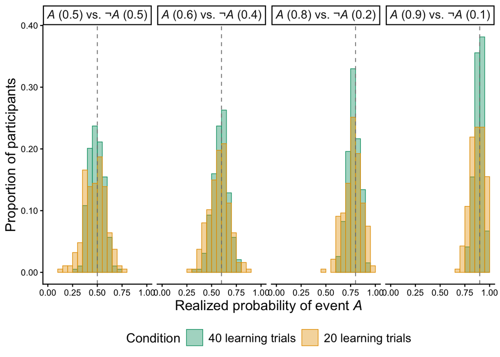

```r
# true p(A) grey reference line ----
df_true_pA <- tibble(
  pair_type = factor(pair_type_levels, levels = pair_type_levels),
  p_A       = c(0.50, 0.60, 0.80, 0.90)
)

# ---- plot ----
# colour-blind safe coloring
cond_colours <- c("high" = "#009E73",   # 40 learning trials
                  "low"  = "#E69F00")   # 20 learning trials

p_dist_cond <- ggplot(df_dist_cond,
                      aes(x = Pr, weight = w, fill = condition, colour = condition)) +
  geom_histogram(aes(y = after_stat(ifelse(count == 0, NA, count))),
                 binwidth = 0.05, boundary = 0, na.rm = TRUE,
                 position = "identity", alpha = 0.4, linewidth = 0.3) +
  geom_vline(data = df_true_pA, aes(xintercept = p_A),
             colour = "grey50", linetype = "dashed", linewidth = 0.4,
             inherit.aes = FALSE) +
  facet_grid(. ~ pair_type, labeller = labeller(pair_type = strip_format)) +
  scale_fill_manual(name = "Condition", values = cond_colours,
                    labels = condition_labels,
                    aesthetics = c("fill", "colour")) +
  scale_x_continuous(breaks = c(0, 0.25, 0.5, 0.75, 1)) +
  scale_y_continuous(labels = function(x) sprintf("%.2f", x)) +
  coord_cartesian(xlim = c(0, 1)) +
  labs(x = "Realized probability of event *A*",
       y = "Proportion of participants") +
  theme_classic() +
  theme(strip.text   = element_markdown(size = 12),
        axis.title.x = element_markdown(size = 14),
        axis.title.y = element_markdown(size = 14),
        legend.position = "bottom",
        legend.title = element_text(size = 13),
        legend.text  = element_text(size = 12))

p_dist_cond
```

```r
ggsave("realized_P(A)s.pdf", width = 12, height = 6)
```

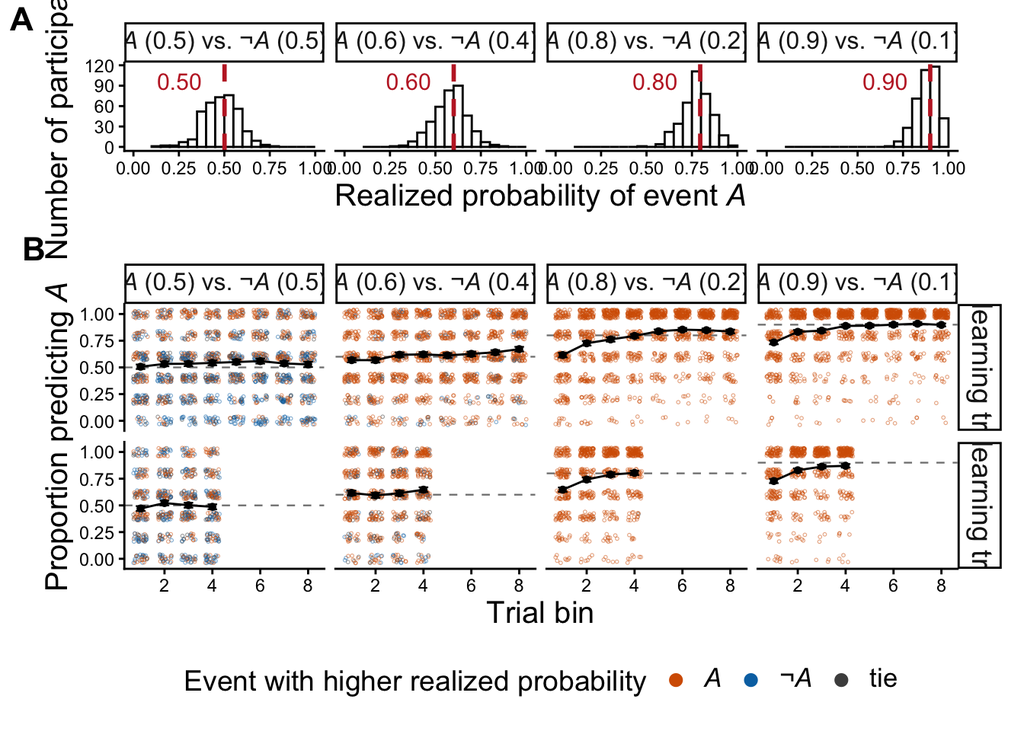

```r
strip_format <- as_labeller(function(x) {
  x <- gsub("(\\d\\.\\d)0\\b", "\\1", x)  # 0.50 -> 0.5 (keep leading zero)
  x <- gsub("not-A", "\u00acA", x)     # not-A -> ¬A, as in the manuscript
  x <- gsub(" vs ", " vs. ", x)
  gsub("A\\b", "*A*", x)              # italicize A (also after ¬)
})

condition_labels <- c("high" = "40 learning trials",
                      "low"  = "20 learning trials")

df_dist <- df_learning_summary |>
  distinct(id,
           `realized_A_0.50`, `realized_A_0.60`,
           `realized_A_0.80`, `realized_A_0.90`) |>
  pivot_longer(starts_with("realized_A"),
               names_to = "pair_type", values_to = "Pr") |>
  mutate(
    pair_type = recode(pair_type,
                       "realized_A_0.50" = "A (0.50) vs not-A (0.50)",
                       "realized_A_0.60" = "A (0.60) vs not-A (0.40)",
                       "realized_A_0.80" = "A (0.80) vs not-A (0.20)",
                       "realized_A_0.90" = "A (0.90) vs not-A (0.10)"),
    pair_type = factor(pair_type, levels = pair_type_levels)
  )

df_dist_means <- df_dist |>
  group_by(pair_type) |>
  summarise(Pr_mean = mean(Pr), .groups = "drop")

p_dist <- ggplot(df_dist, aes(x = Pr)) +
  geom_histogram(binwidth = 0.05, boundary = 0,
                 fill = "white", colour = "black") +
  geom_vline(data = df_dist_means, aes(xintercept = Pr_mean),
             colour = "#c1272d", linetype = "dashed", linewidth = 1) +
  geom_text(data = df_dist_means,
            aes(x = Pr_mean, y = Inf,
                label = sprintf("%.2f", Pr_mean)),
            colour = "#c1272d",
            hjust = 1.5, vjust = 1.6, size = 4) +
  facet_grid(. ~ pair_type, labeller = labeller(pair_type = strip_format)) +
  scale_x_continuous(breaks = c(0, 0.25, 0.5, 0.75, 1)) +
  coord_cartesian(xlim = c(0, 1)) +
  labs(x = "Realized probability of event *A*", y = "Number of participants") +
  theme_classic() +
  theme(strip.text = element_markdown(size = 12),
        plot.tag.position = c(0, 1.02))

# reference line at p(A) for each pair type
df_ref <- tibble(
  pair_type = factor(pair_type_levels, levels = pair_type_levels),
  p_A       = c(0.50, 0.60, 0.80, 0.90)
)

# learning curves
p_main <- ggplot(df_learning_summary, aes(x = phase, y = prop_A)) +
  geom_hline(data = df_ref, aes(yintercept = p_A),
             colour = "grey50", linetype = "dashed", linewidth = 0.4) +
  geom_jitter(aes(colour = optimal_choice),
              position = position_jitter(width = 0.3, height = 0.04, seed = 1),
              shape = 1, size = 0.6, stroke = 0.3, alpha = 0.5) +
  stat_summary(fun.data = mean_se, geom = "errorbar", width = 0.4,
               linewidth = 0.4, colour = "black", aes(group = 1)) +
  stat_summary(fun = mean, geom = "line", linewidth = 0.5,
               colour = "black", aes(group = 1)) +
  stat_summary(fun = mean, geom = "point", size = 1.2,
               colour = "black", aes(group = 1)) +
  scale_colour_manual(
    name   = "Event with higher realized probability",
    values = c("A" = "#D55E00", "not-A" = "#0072B2", "tie" = "#4D4D4D"),
    labels = c("A" = "*A*", "not-A" = "\u00ac*A*", "tie" = "tie")) +
  guides(colour = guide_legend(
    override.aes = list(shape = 16, size = 3, alpha = 1))) +
  facet_grid(condition ~ pair_type,
             labeller = labeller(pair_type = strip_format,
                                 condition = condition_labels)) +
  scale_x_continuous(breaks = c(2, 4, 6, 8)) +
  labs(x = "Trial bin", y = "Proportion predicting *A*") +
  theme_classic() +
  theme(
    strip.text.x = element_markdown(size = 12),
    strip.text.y = element_markdown(size = 14)
  )

# stack two plots, aligned by the pair_type columns
p_combined <- p_dist / p_main +
  plot_layout(heights = c(1, 3), guides = "collect") +
  plot_annotation(tag_levels = "A") &
  theme(
    legend.position = "bottom",
    axis.title.x = element_markdown(size = 15),
    axis.title.y = element_markdown(size = 15),
    legend.title = element_text(size = 14),
    legend.text  = element_markdown(size = 13),
    plot.tag     = element_text(size = 16, face = "bold")
  )

p_combined
```

```r
ggsave("learning.pdf", width = 12, height = 8)
```

### Inferential statistics

We define successful learning as sensitivity to experienced frequency: If participants learned, then the more often *A* actually occurred for a given participant, the more often they should predict *A*.

```r
item_A <- c(A60 = "banana", A50 = "strawberry", A80 = "carrot", A90 = "broccoli")

df_learning2 <- df_learning |>
  mutate(id = factor(id)) |>
  mutate(
    pair  = case_when(bc_box ~ "A60", os_box ~ "A50", ct_box ~ "A80", br_box ~ "A90"),
    trial = case_when(pair == "A60" ~ bc_order, pair == "A50" ~ os_order,
                      pair == "A80" ~ ct_order, pair == "A90" ~ br_order),
    bin   = case_when(pair == "A60" ~ bc_phase, pair == "A50" ~ os_phase,
                      pair == "A80" ~ ct_phase, pair == "A90" ~ br_phase),
    drawn     = coalesce(drawn_fruit, drawn_veggie),
    A_item    = item_A[pair],
    predict_A = as.integer(str_remove(button_chosen, "\\.svg$") == A_item), #1 = event A and 0 = not-A
    outcome_A = as.integer(str_remove(drawn,         "\\.svg$") == A_item), #1 = event A and 0 = not-A
    condition = factor(if_else(condition %in% c("A", "B"), "20", "40"), levels = c("20", "40")),
    pair = factor(pair, levels = c("A50", "A60", "A80", "A90"))
  ) |>
  select(id, condition, pair, trial, bin, drawn, A_item, predict_A, outcome_A) |>
  group_by(id, pair) |>
  mutate(realized_pA   = mean(outcome_A)) |>
  ungroup() |>
  mutate(rpA10    = (realized_pA   - .5) * 10,   # unit = .10, 0 at .50
  )

df_learning_bin <- df_learning2 |>
  group_by(id, condition, pair, bin) |>
  summarise(
    k = sum(predict_A),
    n = n(),
    rpA10 = first(rpA10),
    .groups = "drop"
  )
```

```r
ctrl <- glmerControl(optimizer = "bobyqa", optCtrl = list(maxfun = 2e5))

fit_group <- function(cond) {
  dg <- df_learning_bin |> filter(condition == cond)
  # learning test: does sensitivity change across bins? (bin as factor, no linearity assumption)
  m  <- glmer(cbind(k, n - k) ~ rpA10 * factor(bin) + (1 + rpA10 | id),
              data = dg, family = binomial, control = ctrl)
  m0 <- glmer(cbind(k, n - k) ~ rpA10 + factor(bin) + (1 + rpA10 | id),
              data = dg, family = binomial, control = ctrl)
  cat("\n==== condition", cond, "====\n")
  print(anova(m0, m))                                   # Q1: learning occurred?
  st <- emtrends(m, ~ bin, var = "rpA10")               # per-bin slope
  print(summary(st, infer = TRUE))
  print(contrast(st, "consec"))                         # Q2: which bin-to-bin jumps are ~0 = plateau
}


fit_group("20")
```

```
==== condition 20 ====
Data: dg
Models:
m0: cbind(k, n - k) ~ rpA10 + factor(bin) + (1 + rpA10 | id)
m: cbind(k, n - k) ~ rpA10 * factor(bin) + (1 + rpA10 | id)
   npar    AIC    BIC  logLik -2*log(L)  Chisq Df Pr(>Chisq)
m0    8 9433.1 9481.1 -4708.6    9417.1
m    11 9306.0 9372.1 -4642.0    9284.0 133.07  3  < 2.2e-16 ***
---
Signif. codes:  0 '***' 0.001 '**' 0.01 '*' 0.05 '.' 0.1 ' ' 1
 bin rpA10.trend     SE  df asymp.LCL asymp.UCL z.ratio p.value
   1       0.297 0.0357 Inf     0.227     0.367   8.314 <0.0001
   2       0.453 0.0367 Inf     0.381     0.525  12.320 <0.0001
   3       0.577 0.0377 Inf     0.503     0.651  15.296 <0.0001
   4       0.624 0.0382 Inf     0.549     0.699  16.339 <0.0001

Confidence level used: 0.95
 contrast    estimate     SE  df z.ratio p.value
 bin2 - bin1   0.1555 0.0298 Inf   5.209 <0.0001
 bin3 - bin2   0.1242 0.0318 Inf   3.906  0.0003
 bin4 - bin3   0.0474 0.0333 Inf   1.426  0.3564

P value adjustment: mvt method for 3 tests
```

```r
fit_group("40")
```

```
==== condition 40 ====
Data: dg
Models:
m0: cbind(k, n - k) ~ rpA10 + factor(bin) + (1 + rpA10 | id)
m: cbind(k, n - k) ~ rpA10 * factor(bin) + (1 + rpA10 | id)
   npar   AIC   BIC  logLik -2*log(L)  Chisq Df Pr(>Chisq)
m0   12 18362 18442 -9168.7     18338
m    19 18173 18301 -9067.5     18135 202.45  7  < 2.2e-16 ***
---
Signif. codes:  0 '***' 0.001 '**' 0.01 '*' 0.05 '.' 0.1 ' ' 1
 bin rpA10.trend     SE  df asymp.LCL asymp.UCL z.ratio p.value
   1       0.284 0.0354 Inf     0.215     0.354   8.038 <0.0001
   2       0.447 0.0363 Inf     0.376     0.518  12.304 <0.0001
   3       0.482 0.0367 Inf     0.410     0.554  13.108 <0.0001
   4       0.569 0.0375 Inf     0.495     0.642  15.147 <0.0001
   5       0.621 0.0381 Inf     0.547     0.696  16.309 <0.0001
   6       0.612 0.0382 Inf     0.537     0.687  16.016 <0.0001
   7       0.645 0.0385 Inf     0.570     0.720  16.760 <0.0001
   8       0.630 0.0383 Inf     0.555     0.706  16.441 <0.0001

Confidence level used: 0.95
 contrast    estimate     SE  df z.ratio p.value
 bin2 - bin1   0.1627 0.0313 Inf   5.193 <0.0001
 bin3 - bin2   0.0346 0.0327 Inf   1.059  0.8633
 bin4 - bin3   0.0870 0.0339 Inf   2.568  0.0643
 bin5 - bin4   0.0527 0.0352 Inf   1.495  0.5762
 bin6 - bin5  -0.0090 0.0359 Inf  -0.250  1.0000
 bin7 - bin6   0.0327 0.0363 Inf   0.901  0.9308
 bin8 - bin7  -0.0145 0.0364 Inf  -0.399  0.9992

P value adjustment: mvt method for 7 tests
```

```r
df_cum <- df_learning2 |>
  arrange(id, pair, trial) |>
  group_by(id, pair) |>
  mutate(run_pA = dplyr::lag(cummean(outcome_A))) |>   # frequency seen BEFORE this trial
  ungroup() |>
  filter(!is.na(run_pA)) |>                            # drop trial 1
  mutate(runpA10 = (run_pA - .5) * 10)

df_cum_bin <- df_cum |>
  group_by(id, condition, pair, bin) |>
  summarise(k = sum(predict_A), n = n(),
            runpA10 = mean(runpA10), .groups = "drop")   # mean running-freq within bin

fit_cum <- function(cond) {
  dg <- df_cum_bin |> filter(condition == cond)
  m  <- glmer(cbind(k, n - k) ~ runpA10 * factor(bin) + (1 + runpA10 | id),
              data = dg, family = binomial, control = ctrl)
  m0 <- glmer(cbind(k, n - k) ~ runpA10 + factor(bin) + (1 + runpA10 | id),
              data = dg, family = binomial, control = ctrl)
  cat("\n==== cumulative, condition", cond, "====\n")
  print(anova(m0, m))
  print(summary(emtrends(m, ~ bin, var = "runpA10"), infer = TRUE))
  print(contrast(emtrends(m, ~ bin, var = "runpA10"), "consec"))
}
fit_cum("20")
```

```
==== cumulative, condition 20 ====
Data: dg
Models:
m0: cbind(k, n - k) ~ runpA10 + factor(bin) + (1 + runpA10 | id)
m: cbind(k, n - k) ~ runpA10 * factor(bin) + (1 + runpA10 | id)
   npar    AIC    BIC  logLik -2*log(L)  Chisq Df Pr(>Chisq)
m0    8 8782.7 8830.7 -4383.3    8766.7
m    11 8639.9 8706.0 -4309.0    8617.9 148.73  3  < 2.2e-16 ***
---
Signif. codes:  0 '***' 0.001 '**' 0.01 '*' 0.05 '.' 0.1 ' ' 1
 bin runpA10.trend     SE  df asymp.LCL asymp.UCL z.ratio p.value
   1         0.295 0.0279 Inf     0.240     0.350  10.572 <0.0001
   2         0.453 0.0306 Inf     0.394     0.513  14.823 <0.0001
   3         0.550 0.0326 Inf     0.486     0.614  16.864 <0.0001
   4         0.590 0.0336 Inf     0.525     0.656  17.586 <0.0001

Confidence level used: 0.95
 contrast    estimate     SE  df z.ratio p.value
 bin2 - bin1   0.1584 0.0244 Inf   6.499 <0.0001
 bin3 - bin2   0.0965 0.0291 Inf   3.315  0.0026
 bin4 - bin3   0.0404 0.0321 Inf   1.260  0.4567

P value adjustment: mvt method for 3 tests
```

```r
fit_cum("40")
```

```
==== cumulative, condition 40 ====
Data: dg
Models:
m0: cbind(k, n - k) ~ runpA10 + factor(bin) + (1 + runpA10 | id)
m: cbind(k, n - k) ~ runpA10 * factor(bin) + (1 + runpA10 | id)
   npar   AIC   BIC  logLik -2*log(L)  Chisq Df Pr(>Chisq)
m0   12 17585 17666 -8780.4     17561
m    19 17328 17456 -8645.2     17290 270.43  7  < 2.2e-16 ***
---
Signif. codes:  0 '***' 0.001 '**' 0.01 '*' 0.05 '.' 0.1 ' ' 1
 bin runpA10.trend     SE  df asymp.LCL asymp.UCL z.ratio p.value
   1         0.304 0.0287 Inf     0.248     0.360  10.598 <0.0001
   2         0.461 0.0309 Inf     0.400     0.522  14.904 <0.0001
   3         0.466 0.0321 Inf     0.403     0.529  14.508 <0.0001
   4         0.556 0.0336 Inf     0.490     0.622  16.570 <0.0001
   5         0.633 0.0348 Inf     0.565     0.701  18.217 <0.0001
   6         0.604 0.0348 Inf     0.536     0.672  17.332 <0.0001
   7         0.640 0.0354 Inf     0.571     0.710  18.065 <0.0001
   8         0.630 0.0355 Inf     0.561     0.700  17.737 <0.0001

Confidence level used: 0.95
 contrast    estimate     SE  df z.ratio p.value
 bin2 - bin1  0.15686 0.0237 Inf   6.607 <0.0001
 bin3 - bin2  0.00477 0.0276 Inf   0.173  1.0000
 bin4 - bin3  0.09035 0.0305 Inf   2.966  0.0200
 bin5 - bin4  0.07701 0.0331 Inf   2.323  0.1208
 bin6 - bin5 -0.02928 0.0344 Inf  -0.851  0.9461
 bin7 - bin6  0.03625 0.0350 Inf   1.034  0.8751
 bin8 - bin7 -0.00973 0.0357 Inf  -0.272  0.9999

P value adjustment: mvt method for 7 tests
```

### Subsample preparation for robustness analysis

Criterion: over the last 10 learning trials for each edge pair (the final two 5-trial bins), the participant predicted event *A* on more than half of trials. Both edge pairs must pass.

The 10-trial windows in both learning-trial conditions (20-trial: bins 3-4; 40-trial: bins 7-8) fall inside the learning plateau.

```r
included_ids <- df_learning_bin |>
  filter(pair %in% c("A80", "A90")) |>
  group_by(id, pair) |>
  slice_max(bin, n = 2, with_ties = FALSE) |>        # last 10 trials per edge pair
  summarise(prop_A = sum(k) / sum(n), .groups = "drop") |>
  group_by(id) |>
  summarise(pass = sum(prop_A > 0.5) == 2, .groups = "drop") |>   # both pairs
  filter(pass) |>
  dplyr::pull(id)

# retention by condition
df_learning2 |> distinct(id, condition) |>
  count(condition, kept = id %in% included_ids)
```

```
# A tibble: 4 × 3
  condition kept      n
  <fct>     <lgl> <int>
1 20        FALSE    40
2 20        TRUE    147
3 40        FALSE    31
4 40        TRUE    163
```

```r
#save subsample ids
saveRDS(included_ids, "subsample_ids.rds")
```